# Homework 3

Matthew Farr

October 27, 2016

FW 849 Fall 2014 HW3: Model comparison and model checking

The cpus dataset in R can be found using: >library(MASS) >data(cpus) It includes a relative measure of performance and characteristics of 209 cpus. For more details about this dataset, please use the help command: >?cpus

This dataset is often used to illustrate model selection in regression. We will use this data in this HW. HINT: use the provided R code to upload and standardize the data.

A preliminary analysis has found that the variables mmin (minimum main memory), mmax (maximum main memory), cach (cache size) and chmax (maximum number of chanels) allow to build a model with good predictive properties for the performance measure variable (perf). Please answer the following questions:

1. Write a linear regression model that allows to predict performance using the 4 listed predictor variables (assume indepdendently and identically distributed errors), make sure to include all prior assumptions. (20 points)

See BUGS Model for the linear regression.

2. Fit the model using OpenBUGS. Provide convergence diagnostics (10 points) and posterior distribution of parameters of interest: linear coefficients and error variance (10). HINT: be careful with computational cost! Start with small number of iterations (5000) and perform diagnostics only on linear parameters and precision. Once you decide the number of iterations and burn in, you can start monitoring other quantities.

See Model 1 Test for test run posterior distributions and convergence diagnostics.

See Model 1 for full run posterior distributions and convergence diagnostics. Note that Gelman and Rubin diagnostic is contained within the summary output under rhat.

3. Assess the posterior predictive distribution of FUTURE observations. Hint: a graphic of predicted versus observed or residuals versus observed could be used, BUT make sure you generate FUTURE observations. (20 points)

See Future vs Observed Residuals to assess the model fit for FUTURE observations. The plot suggest that the model has good fit, and would be able to predict FUTURE observations.

4. An alternative model to the presented model is the model that excludes mmin and chmax (model that predicts perf using only mmax and cach). Fit this model using OpenBUGS (20 points)

The BUGS Model was reused, but the data was reformatted to exlude “mmin” and “chmax.” See Model 2 for full run posterior distributions and convergence diagnostics. Note that Gelman and Rubin diagnostic is contained within the summary output under rhat.

5. If you have to choose between the model in 1) and the model in 4), which one would you choose and why? HINT: if you want to re-fit the model to extract predictive criteria, monitor the minimum number of parameters to minimize memory use and output.

The DIC comparison shows that Model 1 better fits the data than Model 2. Thus the full model is better than the model when removing mmin and chmax and those 2 predictors are important in describing the performance of CPUs.

Load Packages and Data

```r
library(MASS)
library(coda)
library(jagsUI)
data(cpus)

y<-cpus$perf
x<-as.matrix(cpus[,c("mmin","mmax","cach","chmax")])
x<-apply(x,2,scale)
head(x)
```

```
##            mmin       mmax      cach       chmax
## [1,] -0.6734091 -0.4942755 5.6805690  4.22089912
## [2,]  1.3231141  1.7229127 0.1672280  0.52821054
## [3,]  1.3231141  1.7229127 0.1672280  0.52821054
## [4,]  1.3231141  1.7229127 0.1672280  0.52821054
## [5,]  1.3231141  0.3584892 0.1672280 -0.08723756
## [6,]  1.3231141  1.7229127 0.9548481  0.52821054
```

```r
y<-(y-mean(y))/sd(y)

N <- length(y)
p <- length(x[1,])
```

Look at standardized Data

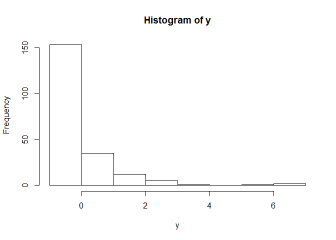

```r
hist(y)
```

BUGS Model

```r
cat("
  model{

  #Priors

  tau ~ dgamma(0.0001, 0.0001)
  for(i in 1:p){
  beta[i] ~ dnorm(0, 0.001)
  }

  #Likelihood
  for(i in 1:N){
  mu[i] <- inprod(x[i,], beta)
  y[i] ~ dnorm(mu[i], tau)
  yfuture[i] ~ dnorm(mu[i], tau)
  e[i] <- y[i] - mu[i]
  enew[i] <- yfuture[i] - mu[i]
  }
  fit <- sum(e[])
  fitnew <- sum(enew[])

  }",fill=TRUE,file="hw3_1.txt")
```

Return to Top

Compile Data, Generate Inits, and Run Test Model

```r
data.regress<-list(y = y, N = N, p = p, x = x)

inits<-function(){
  list(tau=runif(1,0,10)
  )
}

params <-c("beta","tau")

out <- jags(data = data.regress, inits = inits, parameters.to.save = params,
            model.file = "hw3_1.txt", n.chains = 1, n.iter = 5100, n.burnin = 100, n.thin = 1)
```

```
##
## Processing function input.......
##
## Done.
##
##
##
## Adaptive phase, 100 iterations x 1 chains
## If no progress bar appears JAGS has decided not to adapt
##
##
##  Burn-in phase, 100 iterations x 1 chains
##
##
## Sampling from joint posterior, 5000 iterations x 1 chains
##
##
## Calculating statistics.......
```

```
##
## Done.
```

Model 1 Test Posterior Distribution Summary and Convergence Diagnostics

```r
out
```

```
## JAGS output for model 'hw3_1.txt', generated by jagsUI.
## Estimates based on 1 chains of 5100 iterations,
## burn-in = 100 iterations and thin rate = 1,
## yielding 5000 total samples from the joint posterior.
## MCMC ran for 0.005 minutes at time 2016-10-27 17:31:24.
##
##             mean    sd    2.5%     50%   97.5% overlap0 f
## beta[1]    0.358 0.044   0.273   0.357   0.446    FALSE 1
## beta[2]    0.389 0.048   0.294   0.390   0.483    FALSE 1
## beta[3]    0.148 0.034   0.080   0.148   0.214    FALSE 1
## beta[4]    0.233 0.034   0.164   0.233   0.300    FALSE 1
## tau        7.009 0.690   5.710   6.984   8.433    FALSE 1
## deviance 186.998 3.242 182.686 186.344 194.929    FALSE 1
##
## overlap0 checks if 0 falls in the parameter's 95% credible interval.
## f is the proportion of the posterior with the same sign as the mean;
## i.e., our confidence that the parameter is positive or negative.
##
## DIC info: (pD = var(deviance)/2)
## pD = 5.3 and DIC = 192.254
## DIC is an estimate of expected predictive error (lower is better).
```

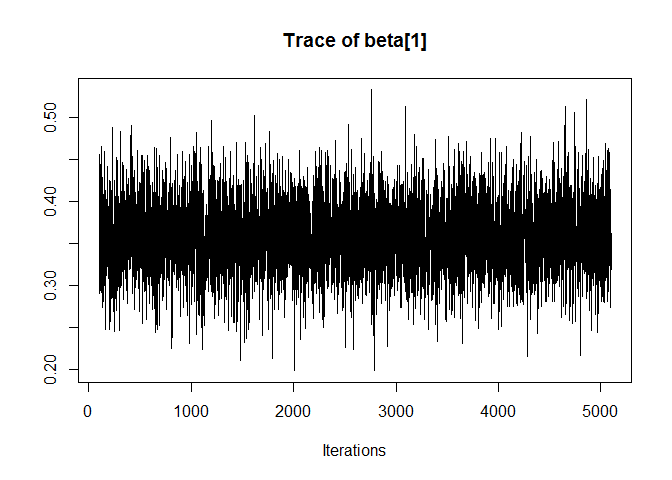

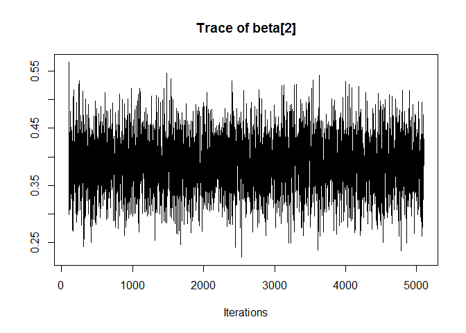

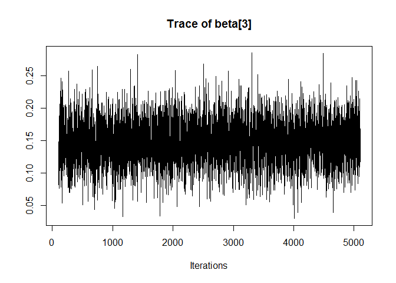

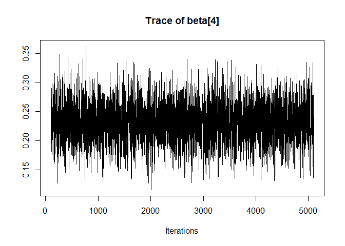

```r
nm.theta <- paste("beta[",1:p,"]",sep="")
beta <- out$samples[[1]][,nm.theta]
traceplot(beta)
```

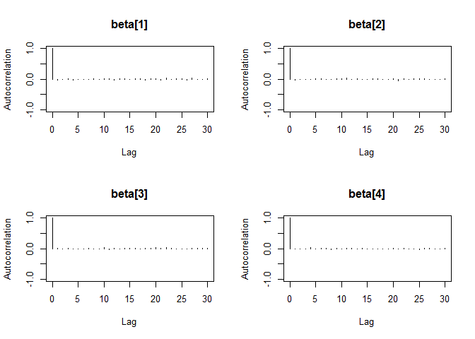

```r
autocorr.plot(beta)
```

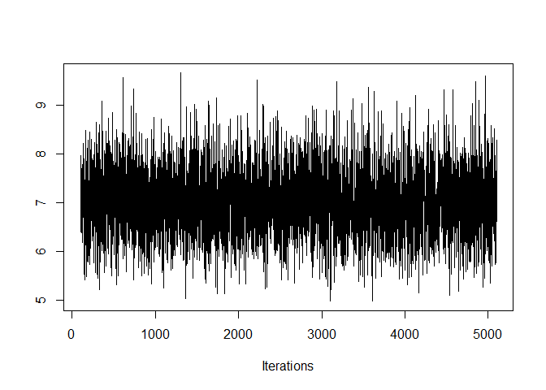

```r
nm.theta <- paste("tau",sep="")
tau <- out$samples[[1]][,nm.theta]
traceplot(tau)
```

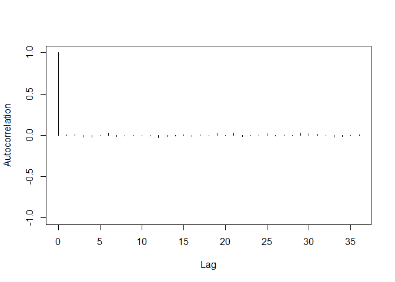

```r
autocorr.plot(tau)
```

Return to Top

Set Parameters and Run Full Model 1

```r
params2 <- c("beta", "tau", "fit", "fitnew")

out2 <- jags(data = data.regress, inits = inits, parameters.to.save = params2,
model.file = "hw3_1.txt", n.chains = 3, n.iter = 15000, n.burnin = 5000, n.thin = 8)
```

```
##
## Processing function input.......
##
## Done.
##
##
##
## Adaptive phase, 100 iterations x 3 chains
## If no progress bar appears JAGS has decided not to adapt
##
##
##  Burn-in phase, 5000 iterations x 3 chains
##
##
## Sampling from joint posterior, 10000 iterations x 3 chains
##
##
## Calculating statistics.......
##
## Done.
```

Full Model 1 Posterior Distribution Summary and Convergence Diagnostics

```r
out2[["summary"]][1:5,]
```

```
##              mean         sd       2.5%       25%       50%       75%
## beta[1] 0.3584187 0.04343105 0.27298087 0.3288986 0.3580263 0.3880736
## beta[2] 0.3888643 0.04820845 0.29583226 0.3556259 0.3886584 0.4221010
## beta[3] 0.1486809 0.03431302 0.08235207 0.1252666 0.1488715 0.1714051
## beta[4] 0.2321486 0.03450303 0.16548390 0.2093484 0.2323988 0.2547066
## tau     7.0112845 0.69510499 5.66525556 6.5317317 7.0034394 7.4761168
##             97.5%     Rhat n.eff overlap0 f
## beta[1] 0.4433627 1.000073  3750        0 1
## beta[2] 0.4859403 1.000113  3750        0 1
## beta[3] 0.2163549 1.000498  3750        0 1
## beta[4] 0.2999942 1.000203  3750        0 1
## tau     8.3766959 1.000272  2985        0 1
```

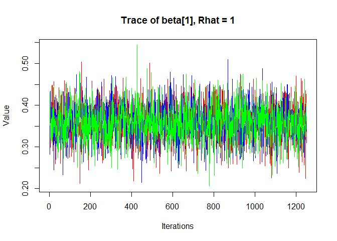

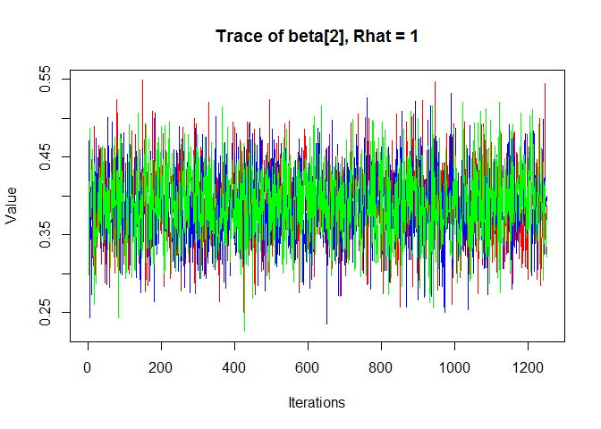

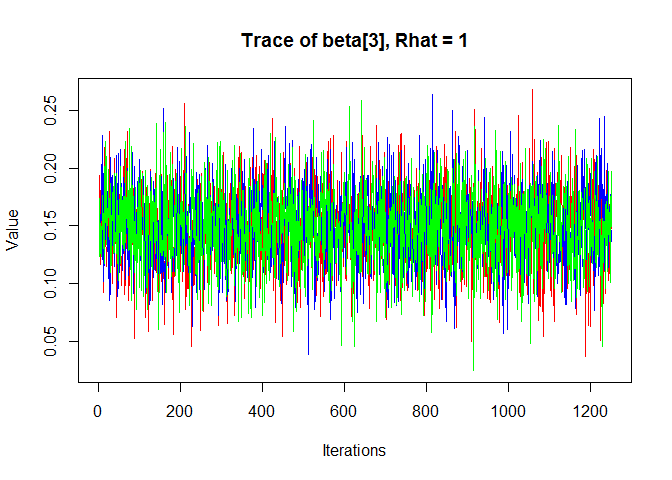

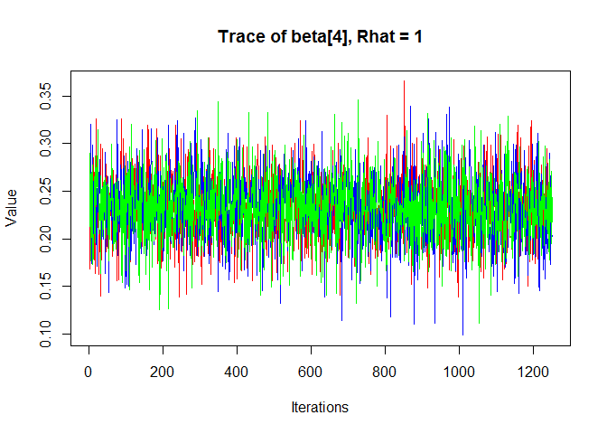

```r
traceplot(out2, "beta")
```

Return to Top

Future Residuals vs Observed Residuals

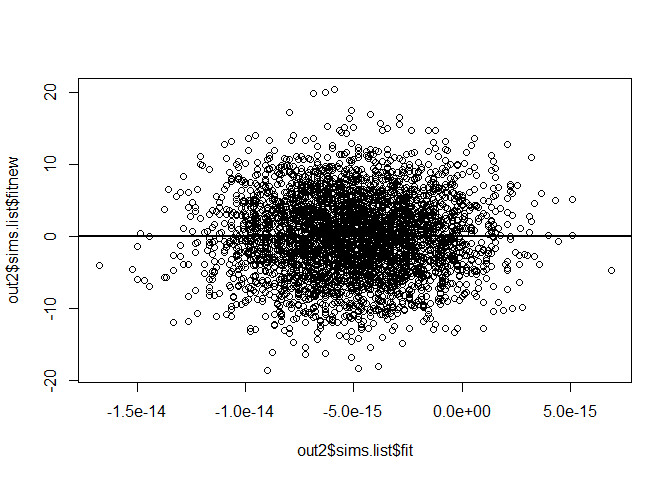

```r
plot(out2$sims.list$fit, out2$sims.list$fitnew)
abline(0,1, lwd = 2, col = "black")
```

Return to Top

Model 2 Reformat and Recompile Data

```r
x1<-as.matrix(cpus[,c("mmax","cach")])
x1<-apply(x1,2,scale)
head(x1)
```

```
##            mmax      cach
## [1,] -0.4942755 5.6805690
## [2,]  1.7229127 0.1672280
## [3,]  1.7229127 0.1672280
## [4,]  1.7229127 0.1672280
## [5,]  0.3584892 0.1672280
## [6,]  1.7229127 0.9548481
```

```r
p1 <- length(x1[1,])

data.regress1<-list(y = y, N = N, p = p1, x = x1)
```

Return to Top

Run Full Model 2

```r
out3 <- jags(data = data.regress1, inits = inits, parameters.to.save = params,
model.file = "hw3_1.txt", n.chains = 3, n.iter = 15000, n.burnin = 5000, n.thin = 8)
```

```
##
## Processing function input.......
##
## Done.
##
##
##
## Adaptive phase, 100 iterations x 3 chains
## If no progress bar appears JAGS has decided not to adapt
##
##
##  Burn-in phase, 5000 iterations x 3 chains
##
##
## Sampling from joint posterior, 10000 iterations x 3 chains
##
##
## Calculating statistics.......
##
## Done.
```

Return to Top

Full Model 2 Posterior Distribution Summary and Convergence Diagnostics

```r
out3[["summary"]][1:3,]
```

```
##              mean         sd      2.5%       25%       50%       75%
## beta[1] 0.7127143 0.03724684 0.6404161 0.6876106 0.7123626 0.7379061
## beta[2] 0.2793986 0.03680358 0.2072741 0.2540355 0.2790458 0.3048541
## tau     4.9754032 0.48292019 4.0883494 4.6426904 4.9565175 5.2882545
##             97.5%      Rhat n.eff overlap0 f
## beta[1] 0.7862381 1.0001106  3750        0 1
## beta[2] 0.3519813 0.9999853  3750        0 1
## tau     5.9712714 1.0000377  3750        0 1
```

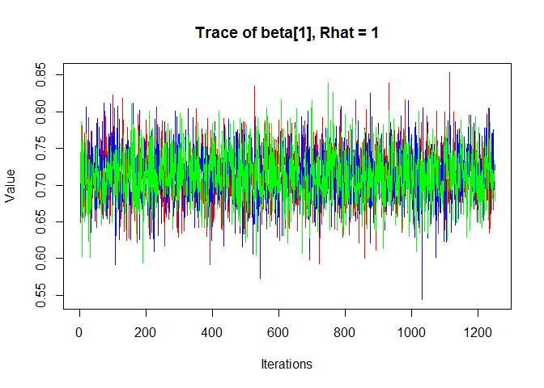

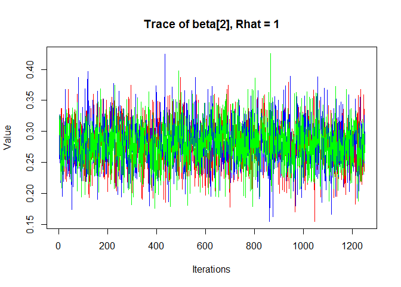

```r
traceplot(out3, "beta")
```

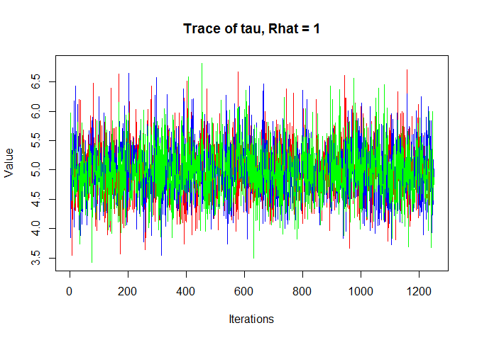

```r
traceplot(out3, "tau")
```

Return to Top

Compare DIC between Model 1 and Model 2

Model1

```r
out2$DIC
```

```
## [1] 192.1735
```

Model2

```r
out3$DIC
```

```
## [1] 261.8292
```

Return to Top